# Automatic report for a Randomized Complete Block Design (RCBD)

International Potato Center

June 09, 2016

# 1. Model specification and data description

There are data from 27 genotypes evaluated using a randomize complete block design with 3 blocks. The statistical model is
$$y_{ij} = \mu + \tau_i + \beta_j + \epsilon_{ij}$$
where

- $y_{ij}$ is the observed response with genotype $i$ and block $j$.
- $\mu$ is the mean response over all genotypes and blocks.
- $\tau_i$ is the effect for genotype $i$.
- $\beta_j$ is the effect for block $j$.
- $\epsilon_{ij}$ is the error term.

In this model we assume that the errors are independent and have a normal distribution with common variance, that is, $\epsilon_{ij} \sim N(0,\sigma_{\epsilon}^2)$.

# 2. Analysis for trait Number of commercial storage roots counting number per plot

## 2.1. ANOVA

You have fitted a linear model for a RCBD. The ANOVA table for your model is:

```
## Analysis of Variance Table
##
## Response: "Number of commercial storage roots counting number per plot"
##               Df  Sum Sq Mean Sq F value   Pr(>F)
## germplasmName 26 10759.6  413.83  2.3027 0.005248 **
## REP            2  2150.9 1075.44  5.9842 0.004581 **
## Residuals     52  9345.1  179.71
## ---
## Signif. codes:  0 '***' 0.001 '**' 0.01 '*' 0.05 '.' 0.1 ' ' 1
```

## 2.2. Assumptions

Don’t forget the assumptions of the model. It is supposed that the errors are independent with a normal distribution and with the same variance for all the genotypes. The following plots must help you evaluate this:

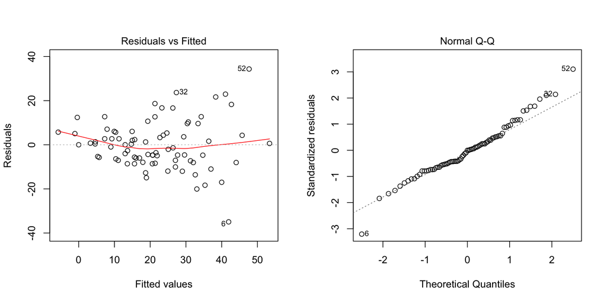

Any trend in the residuals in the left plot would violate the assumption of independence while a trend in the variability of the residuals –for instance a funnel shape– suggests heterogeneity of variances. Departures from the theoretical normal line on the right plot are symptoms of lack of normality.

## 2.3. Genotype means

Below are the sorted means for each genotype with letters indicating if there are significant differences using the multiple comparisons method of Tukey at the 5% level.

```
##             trt     means  M
## 1  MGSG 1051-1  47.666667  a
## 2  MGSG 1010-4  40.000000 ab
## 3  MGSG 1065-4  38.333333 ab
## 4  MGSG 1015-2  37.000000 ab
## 5  MGSG 1061-3  35.333333 ab
## 6  MGSG 1009-3  30.666667 ab
## 7  MGSG 1006-7  29.000000 ab
## 8  MGSG 1010-10 27.666667 ab
## 9  MGSG 1005-17 27.333333 ab
## 10 MGSG 1004-27 26.333333 ab
## 11 MGSG 1006-9  24.666667 ab
## 12 MGSG 1001-7  23.666667 ab
## 13 MGSG 1004-2  21.333333 ab
## 14 MGSG 1011-5  21.333333 ab
## 15 MGSG 1002-49 20.666667 ab
## 16 MGSG 1007-13 19.333333 ab
## 17 MGSG 1012-9  17.000000 ab
## 18 Chingova     15.666667 ab
## 19 MGSG 1001-36 15.000000 ab
## 20 MGSG 1015-17 13.666667 ab
## 21 MGSG 1003-27 13.000000 ab
## 22 Resisto      13.000000 ab
## 23 MGSG 1008-8  10.333333 ab
## 24 MGSG 1007-9   9.000000 ab
## 25 Jonathan      5.333333 ab
## 26 MGSG 1068-1   4.666667  b
## 27 MGSG 1032-3   0.000000  b
```

## 2.4. Variance components

Below are the variance components for this model, under the assumption that genotypes and blocks are random. Here the model is fitted using REML and missing values are not estimated.

```
##                Variance  Std.Dev.
## germplasmName  78.03846  8.833938
## REP            33.17522  5.759793
## Residual      179.71367 13.405733
```